# SanFrancisco Bay Area bike-share

## Preliminary Wrangling

This document is focused on the exploration of a dataset containing around 183k bike trip logs from San Francisco Bay Area during February 2019.

```python
# import all packages and set plots to be embedded inline
import numpy as np
import pandas as pd
import matplotlib.pyplot as plt
import matplotlib as mpl
import seaborn as sb
import folium
import datetime as dt


%matplotlib inline
```

```python
# load in the dataset into a pandas dataframe, print statistics
```

```python
bike=pd.read_csv('201902-fordgobike-tripdata.csv')
```

```python
bike.head()
```

|  | duration_sec | start_time | end_time | start_station_id | start_station_name | start_station_latitude | start_station_longitude | end_station_id | end_station_name | end_station_latitude | end_station_longitude | bike_id | user_type | member_birth_year | member_gender | bike_share_for_all_trip |
| --- | --- | --- | --- | --- | --- | --- | --- | --- | --- | --- | --- | --- | --- | --- | --- | --- |
| 0 | 52185 | 2019-02-28 17:32:10.1450 | 2019-03-01 08:01:55.9750 | 21.0 | Montgomery St BART Station (Market St at 2nd St) | 37.789625 | -122.400811 | 13.0 | Commercial St at Montgomery St | 37.794231 | -122.402923 | 4902 | Customer | 1984.0 | Male | No |
| 1 | 42521 | 2019-02-28 18:53:21.7890 | 2019-03-01 06:42:03.0560 | 23.0 | The Embarcadero at Steuart St | 37.791464 | -122.391034 | 81.0 | Berry St at 4th St | 37.775880 | -122.393170 | 2535 | Customer | NaN | NaN | No |
| 2 | 61854 | 2019-02-28 12:13:13.2180 | 2019-03-01 05:24:08.1460 | 86.0 | Market St at Dolores St | 37.769305 | -122.426826 | 3.0 | Powell St BART Station (Market St at 4th St) | 37.786375 | -122.404904 | 5905 | Customer | 1972.0 | Male | No |
| 3 | 36490 | 2019-02-28 17:54:26.0100 | 2019-03-01 04:02:36.8420 | 375.0 | Grove St at Masonic Ave | 37.774836 | -122.446546 | 70.0 | Central Ave at Fell St | 37.773311 | -122.444293 | 6638 | Subscriber | 1989.0 | Other | No |
| 4 | 1585 | 2019-02-28 23:54:18.5490 | 2019-03-01 00:20:44.0740 | 7.0 | Frank H Ogawa Plaza | 37.804562 | -122.271738 | 222.0 | 10th Ave at E 15th St | 37.792714 | -122.248780 | 4898 | Subscriber | 1974.0 | Male | Yes |

```python
bike.info()
```

```
<class 'pandas.core.frame.DataFrame'>
RangeIndex: 183412 entries, 0 to 183411
Data columns (total 16 columns):
 #   Column                   Non-Null Count   Dtype
---  ------                   --------------   -----
 0   duration_sec             183412 non-null  int64
 1   start_time               183412 non-null  object
 2   end_time                 183412 non-null  object
 3   start_station_id         183215 non-null  float64
 4   start_station_name       183215 non-null  object
 5   start_station_latitude   183412 non-null  float64
 6   start_station_longitude  183412 non-null  float64
 7   end_station_id           183215 non-null  float64
 8   end_station_name         183215 non-null  object
 9   end_station_latitude     183412 non-null  float64
 10  end_station_longitude    183412 non-null  float64
 11  bike_id                  183412 non-null  int64
 12  user_type                183412 non-null  object
 13  member_birth_year        175147 non-null  float64
 14  member_gender            175147 non-null  object
 15  bike_share_for_all_trip  183412 non-null  object
dtypes: float64(7), int64(2), object(7)
memory usage: 22.4+ MB
```

Cleaning notes:

```python
bike.describe()
```

|  | duration_sec | start_station_id | start_station_latitude | start_station_longitude | end_station_id | end_station_latitude | end_station_longitude | bike_id | member_birth_year |
| --- | --- | --- | --- | --- | --- | --- | --- | --- | --- |
| count | 183412.000000 | 183215.000000 | 183412.000000 | 183412.000000 | 183215.000000 | 183412.000000 | 183412.000000 | 183412.000000 | 175147.000000 |
| mean | 726.078435 | 138.590427 | 37.771223 | -122.352664 | 136.249123 | 37.771427 | -122.352250 | 4472.906375 | 1984.806437 |
| std | 1794.389780 | 111.778864 | 0.099581 | 0.117097 | 111.515131 | 0.099490 | 0.116673 | 1664.383394 | 10.116689 |
| min | 61.000000 | 3.000000 | 37.317298 | -122.453704 | 3.000000 | 37.317298 | -122.453704 | 11.000000 | 1878.000000 |
| 25% | 325.000000 | 47.000000 | 37.770083 | -122.412408 | 44.000000 | 37.770407 | -122.411726 | 3777.000000 | 1980.000000 |
| 50% | 514.000000 | 104.000000 | 37.780760 | -122.398285 | 100.000000 | 37.781010 | -122.398279 | 4958.000000 | 1987.000000 |
| 75% | 796.000000 | 239.000000 | 37.797280 | -122.286533 | 235.000000 | 37.797320 | -122.288045 | 5502.000000 | 1992.000000 |
| max | 85444.000000 | 398.000000 | 37.880222 | -121.874119 | 398.000000 | 37.880222 | -121.874119 | 6645.000000 | 2001.000000 |

```python
# Plot the map distribution of the coordinates
basemap=folium.Map(location=[37.774929,-122.419416], zoom_start=8)
plotdata=folium.map.FeatureGroup()
data=bike.drop_duplicates(subset=['start_station_latitude','start_station_longitude'])
for lat, lon in zip(data['start_station_latitude'],data['start_station_longitude']):
    plotdata.add_child(
        folium.CircleMarker(
        [lat,lon],
        radius=0.01,
        color='red',
        fill=True,
        fill_color='red',
        fill_opacity=0.6))

basemap.add_child(plotdata)
```

Make this Notebook Trusted to load map: File -> Trust Notebook

[interactive chart not shown]

Cleaning notes:

> - Duration outliers on the upper side
> - Year of birth - min is 1878 - odd.

### What is the structure of your dataset?

There are 183,412 bike ride logs in the dataset with 16 features (duration, start and end of the trip, start and end stations name, coordinates, and id, bike id and user details – type of user subscription, if the subscriber is enrolled in the Share for all program and the user’s year of birth and gender. Most variables are numeric in nature (year, coordinates, ids), and some are categorical: gender, type of user, station name. The time measures (start and finish of the trip) are strings, so will need to be converted.

### What is/are the main feature(s) of interest in your dataset?

I'm most interested in figuring out if there are any patterns in the characteristics and behavior of the users that will impact the demand at a certain moment in time. I find this important because, as a service provider, you need to know when are your peeks in the demand so you make sure the bikes are available to the customers. So, I will add a measure that specifies the minute of the day that a trip starts.

### What features in the dataset do you think will help support your investigation into your feature(s) of interest?

I expect the location will have an impact and also the user type, age and gender. This is because older people are retired so they might use a bike for leisure, middle age and young people might use the bikes for commuting to work. Subscribers might have a more predictable pattern of renting – I expect the subscribers are professionals or students commuting. Also, if you have a long commute, you will need to pick up a bike earlier so you reach the destination in time. I will need to transform the database in order to have these details, but I will start from the year of birth, the coordinates of stations, the user types and gender.

First step is to cleanup and transform the data:

```python
# convert time values to datetime
bike['start_time']=pd.to_datetime(bike['start_time'])
bike['end_time']=pd.to_datetime(bike['end_time'])
```

```python
# check dataset time-frame
bike['start_time'].min(), bike['start_time'].max()
```

```
(Timestamp('2019-02-01 00:00:20.636000'),
 Timestamp('2019-02-28 23:59:18.548000'))
```

```python
# extract day of the month
bike['start_day'] = bike['start_time'].dt.day
bike['end_day'] =bike['end_time'].dt.day
```

```python
# create measures of start of trip as the minute of the day
bike['start_min'] = bike['start_time'].dt.minute
bike['end_min'] = bike['end_time'].dt.minute
bike['start_h'] = bike['start_time'].dt.hour
bike['end_h'] = bike['end_time'].dt.hour
bike['start_mom'] = bike['start_min']+60*bike['start_h']
bike['end_mom'] = bike['end_min']+60*bike['end_h']
```

```python
#create a table containing all stations
coord1=bike[['end_station_name','end_station_latitude','end_station_longitude']].copy(deep=True)
coord1.rename(columns={'end_station_name':'name','end_station_latitude':'lat','end_station_longitude':'lon'}, inplace=True)
coord2=bike[['start_station_name','start_station_latitude','start_station_longitude']].copy(deep=True)
coord2.rename(columns={'start_station_name':'name','start_station_latitude':'lat','start_station_longitude':'lon'}, inplace=True)
coord=coord1.append(coord2)
coord.drop_duplicates(inplace=True)
coord.info()
```

```
<class 'pandas.core.frame.DataFrame'>
Int64Index: 346 entries, 0 to 155578
Data columns (total 3 columns):
 #   Column  Non-Null Count  Dtype
---  ------  --------------  -----
 0   name    329 non-null    object
 1   lat     346 non-null    float64
 2   lon     346 non-null    float64
dtypes: float64(2), object(1)
memory usage: 10.8+ KB
```

```python
# add labels by location cluster - major city in the area
coord['sj']=coord.lat.apply(lambda x: "SanJose" if x<37.4 else "")
coord['oak']=coord.lon.apply(lambda x: "Oakland" if x>-122.35 else "")
coord['sf']=coord.lon.apply(lambda x: "SanFrancisco" if x<-122.35 else "")
coord['cluster']=coord['sj']+coord['oak']+coord['sf']

coord.cluster=coord.cluster.str.replace(pat="SanJoseOakland", repl="SanJose")
coord.cluster.value_counts()
```

```
SanFrancisco    156
Oakland         140
SanJose          50
Name: cluster, dtype: int64
```

```python
# remove missing values in the data and copy in a new df
bike2=bike.dropna().copy(deep=True)
```

```python
# add the name of the cluster for the start trip
coord.rename(columns={'name':'end_station_name'},inplace=True)
bike2=pd.merge(bike2,coord, how='left',on='end_station_name' )
bike2=bike2.drop(columns=['lat','lon','sj','oak','sf'])
bike2.rename(columns={'cluster':'end_cluster'},inplace=True)
```

```python
# add the name of the cluster for the start trip
coord.rename(columns={'end_station_name':'start_station_name'},inplace=True)
bike2=pd.merge(bike2,coord, how='left',on='start_station_name' )
bike2=bike2.drop(columns=['lat','lon','sj','oak','sf'])
bike2.rename(columns={'cluster':'start_cluster'},inplace=True)
```

```python
# check how many trips are happening bewtween clusters
bike2['same_cluster']=bike2['start_cluster']==bike2['end_cluster']
bike2['same_cluster'].value_counts()
```

```
True     174943
False         9
Name: same_cluster, dtype: int64
```

```python
# remove trips between clusters
bike2.drop(columns=['same_cluster'],inplace=True)
```

```python
# create a measure for age (as difference between 2019 and year of birth) and check how many are very old
bike2['age']=2019-bike2.member_birth_year
bike2['age'].value_counts()
```

```
31.0     10214
26.0      9323
30.0      8967
29.0      8640
28.0      8484
         ...
89.0         1
92.0         1
91.0         1
109.0        1
141.0        1
Name: age, Length: 75, dtype: int64
```

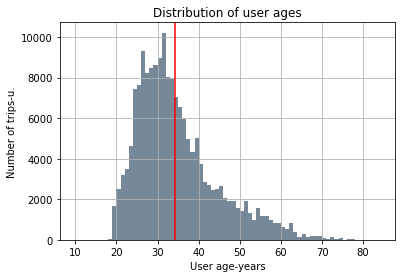

```python
# plot the distribution of trips by age
bike2.age.hist(bins=np.arange(10,85,1), color='lightslategrey')
plt.axvline(bike2.age.mean(),color='r')
plt.title('Distribution of user ages')
plt.xlabel('User age-years');
plt.ylabel('Number of trips-u.');
```

```python
#check records with people over 90
bike2[bike2['age']>90]
```

|  | duration_sec | start_time | end_time | start_station_id | start_station_name | start_station_latitude | start_station_longitude | end_station_id | end_station_name | end_station_latitude | ... | end_day | start_min | end_min | start_h | end_h | start_mom | end_mom | end_cluster | start_cluster | age |
| --- | --- | --- | --- | --- | --- | --- | --- | --- | --- | --- | --- | --- | --- | --- | --- | --- | --- | --- | --- | --- | --- |
| 1238 | 148 | 2019-02-28 19:29:17.627 | 2019-02-28 19:31:45.967 | 158.0 | Shattuck Ave at Telegraph Ave | 37.833279 | -122.263490 | 173.0 | Shattuck Ave at 55th St | 37.840364 | ... | 28 | 29 | 31 | 19 | 19 | 1169 | 1171 | Oakland | Oakland | 119.0 |
| 10407 | 1315 | 2019-02-27 19:21:34.436 | 2019-02-27 19:43:30.008 | 343.0 | Bryant St at 2nd St | 37.783172 | -122.393572 | 375.0 | Grove St at Masonic Ave | 37.774836 | ... | 27 | 21 | 43 | 19 | 19 | 1161 | 1183 | SanFrancisco | SanFrancisco | 119.0 |
| 15483 | 1131 | 2019-02-27 08:37:36.864 | 2019-02-27 08:56:28.022 | 375.0 | Grove St at Masonic Ave | 37.774836 | -122.446546 | 36.0 | Folsom St at 3rd St | 37.783830 | ... | 27 | 37 | 56 | 8 | 8 | 517 | 536 | SanFrancisco | SanFrancisco | 119.0 |
| 17320 | 366 | 2019-02-26 19:53:38.528 | 2019-02-26 19:59:44.968 | 50.0 | 2nd St at Townsend St | 37.780526 | -122.390288 | 21.0 | Montgomery St BART Station (Market St at 2nd St) | 37.789625 | ... | 26 | 53 | 59 | 19 | 19 | 1193 | 1199 | SanFrancisco | SanFrancisco | 99.0 |
| 18197 | 432 | 2019-02-26 17:48:59.016 | 2019-02-26 17:56:11.370 | 21.0 | Montgomery St BART Station (Market St at 2nd St) | 37.789625 | -122.400811 | 50.0 | 2nd St at Townsend St | 37.780526 | ... | 26 | 48 | 56 | 17 | 17 | 1068 | 1076 | SanFrancisco | SanFrancisco | 99.0 |
| ... | ... | ... | ... | ... | ... | ... | ... | ... | ... | ... | ... | ... | ... | ... | ... | ... | ... | ... | ... | ... | ... |
| 165796 | 993 | 2019-02-03 09:45:30.464 | 2019-02-03 10:02:04.169 | 375.0 | Grove St at Masonic Ave | 37.774836 | -122.446546 | 36.0 | Folsom St at 3rd St | 37.783830 | ... | 3 | 45 | 2 | 9 | 10 | 585 | 602 | SanFrancisco | SanFrancisco | 119.0 |
| 169534 | 1527 | 2019-02-01 19:09:28.387 | 2019-02-01 19:34:55.963 | 343.0 | Bryant St at 2nd St | 37.783172 | -122.393572 | 375.0 | Grove St at Masonic Ave | 37.774836 | ... | 1 | 9 | 34 | 19 | 19 | 1149 | 1174 | SanFrancisco | SanFrancisco | 119.0 |
| 169703 | 517 | 2019-02-01 18:38:40.471 | 2019-02-01 18:47:18.392 | 25.0 | Howard St at 2nd St | 37.787522 | -122.397405 | 30.0 | San Francisco Caltrain (Townsend St at 4th St) | 37.776598 | ... | 1 | 38 | 47 | 18 | 18 | 1118 | 1127 | SanFrancisco | SanFrancisco | 117.0 |
| 174402 | 428 | 2019-02-01 07:45:05.934 | 2019-02-01 07:52:14.922 | 284.0 | Yerba Buena Center for the Arts (Howard St at ... | 37.784872 | -122.400876 | 67.0 | San Francisco Caltrain Station 2 (Townsend St... | 37.776639 | ... | 1 | 45 | 52 | 7 | 7 | 465 | 472 | SanFrancisco | SanFrancisco | 118.0 |
| 174929 | 490 | 2019-02-01 00:39:53.112 | 2019-02-01 00:48:03.338 | 61.0 | Howard St at 8th St | 37.776513 | -122.411306 | 81.0 | Berry St at 4th St | 37.775880 | ... | 1 | 39 | 48 | 0 | 0 | 39 | 48 | SanFrancisco | SanFrancisco | 92.0 |

77 rows × 27 columns

```python
# remove all users aged over 80.
bike2=bike2[bike2['age']<=80].copy(deep=True)
```

```python
# make sure all "share for all subscribers" are subscribers in user_type column
bike2[bike2['bike_share_for_all_trip']=='Yes']['user_type'].value_counts()
```

```
Subscriber    17299
Name: user_type, dtype: int64
```

```python
#convert subscribers that have a "share for all subscribers" subscribers to "Bike4All"
bike2.loc[bike2['bike_share_for_all_trip']=='Yes','user_type']='Bike4All'
```

```python
#check the logarithmic distribution for duration of trip
np.log10(bike2.duration_sec.describe())
```

```
count    5.242442
mean     2.847764
std      3.215646
min      1.785330
25%      2.509203
50%      2.708421
75%      2.897077
max      4.927103
Name: duration_sec, dtype: float64
```

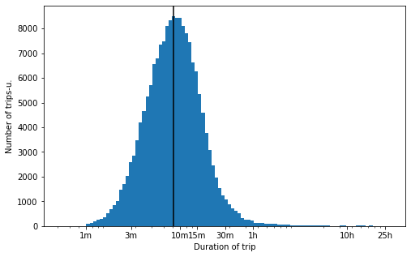

```python
# because there is very high variance in the duration of trips, plot the distribution using a log x axis
log_binsize = 0.035
bn1 = 10 ** np.arange(1.5, 5+log_binsize, log_binsize)
ax1=plt.figure(figsize=[8, 5])
ax1=plt.hist(data = bike2, x = 'duration_sec', bins = bn1)
plt.xscale('log')
plt.xticks([60, 180,600,  900, 1800, 3600, 36000, 90000], ['1m','3m','10m', '15m','30m','1h', '10h', '25h'])
plt.xlabel('Duration of trip')
plt.ylabel('Number of trips-u.')

#add the median for reference
ax=plt.axvline(bike2.duration_sec.median(),color='black')

plt.show()
```

```python
# create a column to check what trips ended one day after the start
bike2['day_dif']=bike2.end_day-bike2.start_day
```

```python
# ckeck all trips that end the next day and are returned after 6 in the morning - the user keept it over night
bike2[(bike2.end_h>6) & (bike2.day_dif>0)].sort_values(by='duration_sec', ascending=False)
```

|  | duration_sec | start_time | end_time | start_station_id | start_station_name | start_station_latitude | start_station_longitude | end_station_id | end_station_name | end_station_latitude | ... | start_min | end_min | start_h | end_h | start_mom | end_mom | end_cluster | start_cluster | age | day_dif |
| --- | --- | --- | --- | --- | --- | --- | --- | --- | --- | --- | --- | --- | --- | --- | --- | --- | --- | --- | --- | --- | --- |
| 81604 | 84548 | 2019-02-16 15:48:25.029 | 2019-02-17 15:17:33.080 | 3.0 | Powell St BART Station (Market St at 4th St) | 37.786375 | -122.404904 | 368.0 | Myrtle St at Polk St | 37.785434 | ... | 48 | 17 | 15 | 15 | 948 | 917 | SanFrancisco | SanFrancisco | 38.0 | 1 |
| 122163 | 83519 | 2019-02-09 15:16:17.537 | 2019-02-10 14:28:17.270 | 72.0 | Page St at Scott St | 37.772406 | -122.435650 | 43.0 | San Francisco Public Library (Grove St at Hyde... | 37.778768 | ... | 16 | 28 | 15 | 14 | 916 | 868 | SanFrancisco | SanFrancisco | 29.0 | 1 |
| 107291 | 83407 | 2019-02-11 16:25:33.069 | 2019-02-12 15:35:40.956 | 77.0 | 11th St at Natoma St | 37.773507 | -122.416040 | 344.0 | 16th St Depot | 37.766349 | ... | 25 | 35 | 16 | 15 | 985 | 935 | SanFrancisco | SanFrancisco | 31.0 | 1 |
| 4987 | 83195 | 2019-02-27 14:47:23.181 | 2019-02-28 13:53:58.433 | 243.0 | Bancroft Way at College Ave | 37.869360 | -122.254337 | 248.0 | Telegraph Ave at Ashby Ave | 37.855956 | ... | 47 | 53 | 14 | 13 | 887 | 833 | Oakland | Oakland | 57.0 | 1 |
| 91253 | 82512 | 2019-02-14 13:56:21.728 | 2019-02-15 12:51:34.315 | 368.0 | Myrtle St at Polk St | 37.785434 | -122.419622 | 44.0 | Civic Center/UN Plaza BART Station (Market St ... | 37.781074 | ... | 56 | 51 | 13 | 12 | 836 | 771 | SanFrancisco | SanFrancisco | 21.0 | 1 |
| ... | ... | ... | ... | ... | ... | ... | ... | ... | ... | ... | ... | ... | ... | ... | ... | ... | ... | ... | ... | ... | ... |
| 140919 | 39478 | 2019-02-06 20:33:03.245 | 2019-02-07 07:31:01.459 | 266.0 | Parker St at Fulton St | 37.862464 | -122.264791 | 266.0 | Parker St at Fulton St | 37.862464 | ... | 33 | 31 | 20 | 7 | 1233 | 451 | Oakland | Oakland | 44.0 | 1 |
| 86886 | 38026 | 2019-02-15 23:35:36.678 | 2019-02-16 10:09:23.627 | 29.0 | O'Farrell St at Divisadero St | 37.782405 | -122.439446 | 29.0 | O'Farrell St at Divisadero St | 37.782405 | ... | 35 | 9 | 23 | 10 | 1415 | 609 | SanFrancisco | SanFrancisco | 30.0 | 1 |
| 162369 | 34941 | 2019-02-03 22:56:36.636 | 2019-02-04 08:38:58.409 | 182.0 | 19th Street BART Station | 37.809013 | -122.268247 | 202.0 | Washington St at 8th St | 37.800754 | ... | 56 | 38 | 22 | 8 | 1376 | 518 | Oakland | Oakland | 21.0 | 1 |
| 131303 | 34477 | 2019-02-07 23:02:24.814 | 2019-02-08 08:37:02.244 | 73.0 | Pierce St at Haight St | 37.771793 | -122.433708 | 67.0 | San Francisco Caltrain Station 2 (Townsend St... | 37.776639 | ... | 2 | 37 | 23 | 8 | 1382 | 517 | SanFrancisco | SanFrancisco | 38.0 | 1 |
| 132224 | 33281 | 2019-02-07 21:59:08.604 | 2019-02-08 07:13:50.176 | 123.0 | Folsom St at 19th St | 37.760594 | -122.414817 | 386.0 | 24th St at Bartlett St | 37.752105 | ... | 59 | 13 | 21 | 7 | 1319 | 433 | SanFrancisco | SanFrancisco | 24.0 | 1 |

79 rows × 28 columns

```python
# remove the trips where the bike was kept overnight because the duration is not a trip per se
bike2=bike2[((bike2.end_h<=6) & (bike2.day_dif!=0)) | (bike2.day_dif==0)].copy(deep=True)
```

[output not shown]

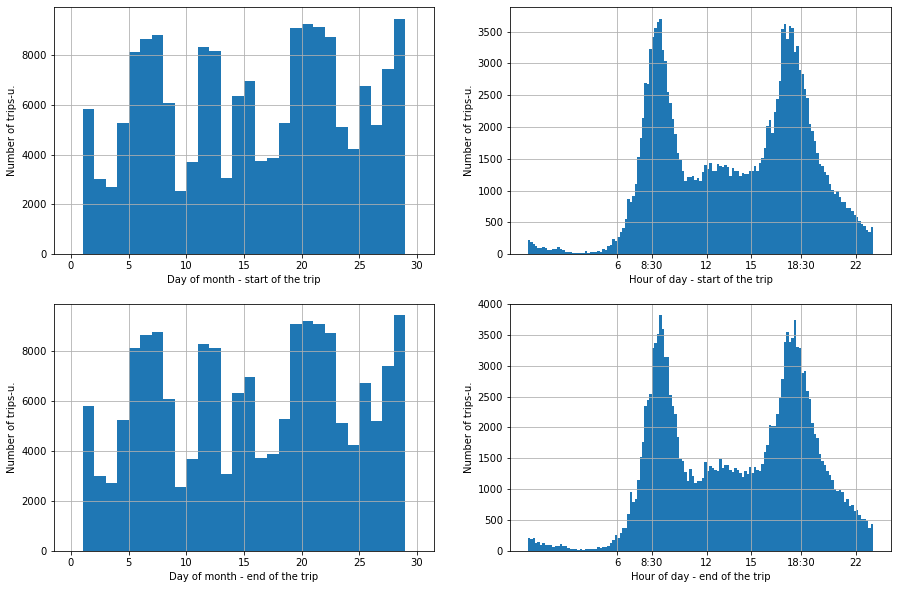

```python
# plot distribution of trips over the month and over the course of the day
fig2=plt.figure(figsize=(15,10))
# start day distribution during the month
ax21=plt.subplot(221)
ax21=bike2.start_day.hist(bins=np.arange(0,31,1))
ax21=plt.xlabel('Day of month - start of the trip')
ax21=plt.ylabel('Number of trips-u.')
# start minute distribution during the day
ax22=plt.subplot(222)
ax22=bike2.start_mom.hist(bins=np.arange(0,1400,10))
ax22=plt.xlabel('Hour of day - start of the trip')
ax22=plt.ylabel('Number of trips-u.')
plt.xticks([360,500,720,900,1100,1320], ['6','8:30','12', '15','18:30','22'])
# end day distribution during the month
ax23=plt.subplot(223)
ax23=bike2.end_day.hist(bins=np.arange(0,31,1))
ax23=plt.xlabel('Day of month - end of the trip')
ax23=plt.ylabel('Number of trips-u.')
# end minute distribution during the day
ax24=plt.subplot(224)
ax24=bike2.end_mom.hist(bins=np.arange(0,1400,10))
ax24=plt.xlabel('Hour of day - end of the trip')
ax24=plt.ylabel('Number of trips-u.')
plt.xticks([360,500,720,900,1100,1320], ['6','8:30','12', '15','18:30','22'])
```

```python
# extract day of the week
bike2['wk_day']=bike['start_time'].apply(lambda x: x.weekday())
```

```python
bike2['wk_day'].value_counts()
```

```
3    35154
1    31755
2    29603
0    26795
4    22812
6    15504
5    13057
Name: wk_day, dtype: int64
```

```python
# label each trip as whether working week or weekend
bike2['wk_day']=bike2['wk_day'].apply(lambda x: 'WeekEnd' if x>=5 else 'WorkWeek')

bike2['wk_day'].value_counts()
```

```
WorkWeek    146119
WeekEnd      28561
Name: wk_day, dtype: int64
```

```python
# convert cluster and type of day to ordered type to keep consistency between shart order elements
clusters=['SanFrancisco', 'Oakland', 'SanJose']
days=['WorkWeek', 'WeekEnd']
loc_cls = pd.api.types.CategoricalDtype(ordered=True, categories=clusters)
day_cls = pd.api.types.CategoricalDtype(ordered=True, categories=days)
# Use pandas.astype() to convert the "VClass" column from a plain object type into an ordered categorical type
bike2['start_cluster'] = bike2['start_cluster'].astype(loc_cls)
bike2['wk_day'] = bike2['wk_day'].astype(day_cls)
```

```python
bike2.head(2)
```

|  | duration_sec | start_time | end_time | start_station_id | start_station_name | start_station_latitude | start_station_longitude | end_station_id | end_station_name | end_station_latitude | ... | end_min | start_h | end_h | start_mom | end_mom | end_cluster | start_cluster | age | day_dif | wk_day |
| --- | --- | --- | --- | --- | --- | --- | --- | --- | --- | --- | --- | --- | --- | --- | --- | --- | --- | --- | --- | --- | --- |
| 1 | 61854 | 2019-02-28 12:13:13.218 | 2019-03-01 05:24:08.146 | 86.0 | Market St at Dolores St | 37.769305 | -122.426826 | 3.0 | Powell St BART Station (Market St at 4th St) | 37.786375 | ... | 24 | 12 | 5 | 733 | 324 | SanFrancisco | SanFrancisco | 47.0 | -27 | WorkWeek |
| 2 | 36490 | 2019-02-28 17:54:26.010 | 2019-03-01 04:02:36.842 | 375.0 | Grove St at Masonic Ave | 37.774836 | -122.446546 | 70.0 | Central Ave at Fell St | 37.773311 | ... | 2 | 17 | 4 | 1074 | 242 | SanFrancisco | SanFrancisco | 30.0 | -27 | WorkWeek |

2 rows × 29 columns

### Discuss the data cleanup and transformation. Did you find any issues with the data?

In order to have the measures I wanted to explore structured I added extra columns:

- Moment of trip start and end (minute of the day)
- Day of the month
- Day of the week
- A label as working week or weekend
- Difference in days between start and end of trip
- Location cluster name of start and end – there are 3 major cities.
- Age as difference between 2019 and the year of birth

The duration variable took on a large range of values, so I plotted the data using a log transform. I created the labels for readability: ticks([60, 180,600, 900, 1800, 3600, 36000, 90000], ['1m','3m','10m', '15m','30m','1h', '10h', '25h'])

Also, for the start of day I labeled based on clock values: ticks([360,500,720,900,1100,1320], ['6','8:30','12', '15','18:30','22'])

## Univariate Exploration

I'll start by looking at the distribution of the main variable of interest: the moment of the day a trip starts.

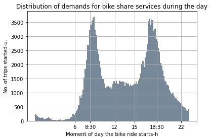

```python
# plot the distribution of moments of the day the trip starts
bike2.start_mom.hist(bins=np.arange(0,1400,10),color='lightslategrey')
plt.xticks([360,500,720,900,1100,1320], ['6','8:30','12', '15','18:30','22'])

plt.title('Distribution of demands for bike share services during the day')
plt.xlabel('Moment of day the bike ride starts-h');
plt.ylabel('No. of trips started-u.');
```

Next is the age of the user:

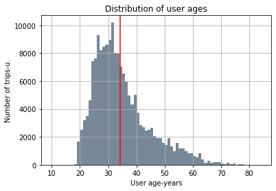

```python
# plot the distribution of age
bike2.age.hist(bins=np.arange(10,85,1), color='lightslategrey')
plt.axvline(bike2.age.mean(),color='r')
plt.title('Distribution of user ages')
plt.xlabel('User age-years');
plt.ylabel('Number of trips-u.');
```

```python
bike2.age.mean(), bike2.age.median()
```

```
(34.1263682161667, 32.0)
```

The age is skewed to right, but that is to be expected since those younger than ~18 could not be customers. The mean is around 34, higher than the median of 32 due to the tail towards older ages. However, most users appear to be between 20 and 40 years of age.

Now, let’s look at the duration of the trip:

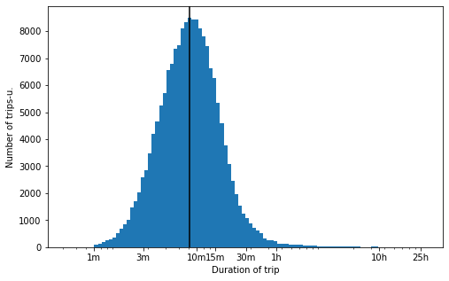

```python
# plot the age using the log x axis
log_binsize = 0.035
bn1 = 10 ** np.arange(1.5, 5+log_binsize, log_binsize)
ax1=plt.figure(figsize=[8, 5])
ax1=plt.hist(data = bike2, x = 'duration_sec', bins = bn1)
plt.xscale('log')
plt.xticks([60, 180,600,  900, 1800, 3600, 36000, 90000], ['1m','3m','10m', '15m','30m','1h', '10h', '25h'])
plt.xlabel('Duration of trip')
plt.ylabel('Number of trips-u.')

#add the median for reference
ax=plt.axvline(bike2.duration_sec.median(),color='black')

plt.show()
```

Next let’s look at the distribution of the stations on the map.

```python
# plot the coordinates on the map
basemap=folium.Map(location=[37.774929,-122.419416], zoom_start=10)
plotdata=folium.map.FeatureGroup()

for lat, lon in zip(coord['lat'],coord['lon']):
    plotdata.add_child(
        folium.CircleMarker(
        [lat,lon],
        radius=0.01,
        color='red',
        fill=True,
        fill_color='red',
        fill_opacity=0.6))

basemap.add_child(plotdata)
```

Make this Notebook Trusted to load map: File -> Trust Notebook

[interactive chart not shown]

As I saw in the beginning, there are 3 clusters – the cities San Francisco, Oakland and San Jose. The San Francisco stations seem a bit more uniformly spread around the city, in Oakland we see a N-S elongated distribution and in San Jose we have some stations outlying to the north.

Now I will look at the distribution of the categorical variables:

```
''
```

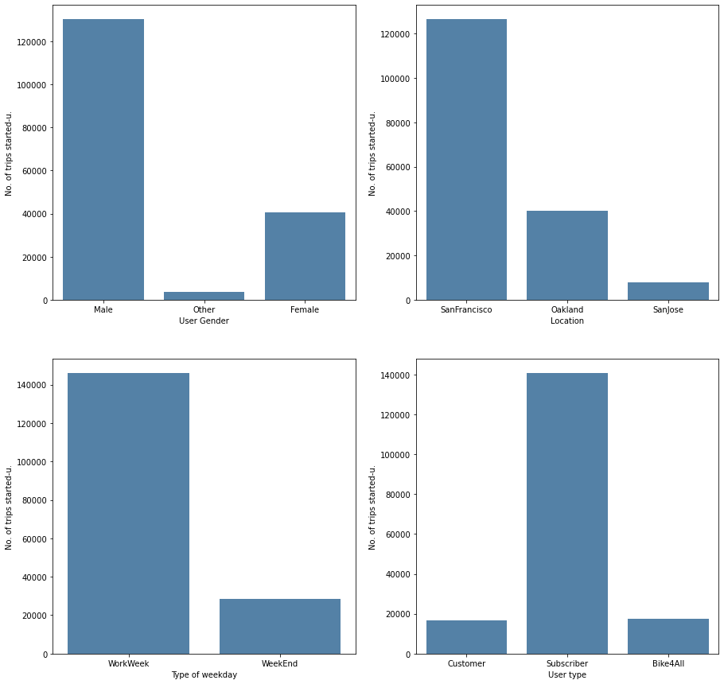

```python
# create a plot for each of the gender, cluster, day of week and customer type
fig1=plt.figure(figsize=(15,15))
ax11=plt.subplot(221)
ax11=sb.countplot(bike2.member_gender, color='steelblue')
ax11=plt.xlabel('User Gender')
ax11= plt.ylabel('No. of trips started-u.')

ax13=plt.subplot(222)
ax13=sb.countplot(bike2.start_cluster, color='steelblue')
ax13= plt.ylabel('No. of trips started-u.')
ax13=plt.xlabel('Location')

ax14=plt.subplot(223)
ax14=sb.countplot(bike2.wk_day, color='steelblue')
ax14=plt.xlabel('Type of weekday')
ax14= plt.ylabel('No. of trips started-u.')

ax15=plt.subplot(224)
ax15=sb.countplot(bike2.user_type, color='steelblue')
ax15=plt.xlabel('User type')
ax15= plt.ylabel('No. of trips started-u.')
;
```

The males appear to be 3 times more numerous than females; there are also other/nonspecific gender users, but the proportion is small.

On the map the number od station between San Francisco and Oakland seemed pretty similar; however, the number of trips from San Francisco are 2-3 times higher which suggests a higher frequency in San Francisco. Also, clearly San Jose has less stations, but the frequency is a lot lower in comparison.

As expected the number of trips during the workweek is higher (there are 5 workday and 2 weekend days), but still the proportion is more than 2.5 as expected by the number of days. This suggests the traffic in the workdays is higher, so probably there are more users that use the bike share to commute to work than for leisure.

The biggest number of rides is attributed to the regular subscribers, the discount subscribers and on/off customers having equal proportions.

### Discuss the distribution(s) of your variable(s) of interest. Were there any unusual points? Did you need to perform any transformations?

I found that the moment of the day has a bimodal distribution peeking at 8:30 in the morning and then at 6:30 in the evening. The interval between 12PM and 3PM is uniform and it has a considerable level too.

### Of the features you investigated, were there any unusual distributions? Did you perform any operations on the data to tidy, adjust, or change the form of the data? If so, why did you do this?

I used the log transformation to view the distance because I found a large variability when I did the data cleanup, and saw that the duration is mostly normally distributed around 10min, most of the trips being between 3 and 30 minutes long. The age of the users is skewed to the right because there are users with ages up to 80 (after cleaning) and the majority is between 20 and 40 years of age.

The stations are distributed in 3 clusters – the cities San Francisco, Oakland and San Jose - San Francisco and Oakland having similar number of stations; The traffic between these clusters is different, San Francisco appearing to have a higher frequency of trips.

The majority of trips are made by male users and subscribers.

Also the traffic seems to be more intense during the work week.

All the data cleanup has been done at the beginning so there was no other issue to be corrected during the analysis.

```python
# add lists of variables to make ploting code easier to read.
categ=['member_gender', 'wk_day','start_cluster', 'user_type']
num=["duration_sec", 'age', 'start_mom']
num2=["log_duration", 'age', 'start_mom']
```

## Bivariate Exploration

To start off with, I want to look at the pairwise correlations present between numerical features in the data.

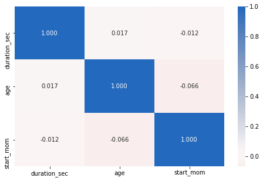

```python
# correlation plot
plt.figure(figsize = [8, 5])
sb.heatmap(bike2[num].corr(), annot = True, fmt = '.3f',
           cmap = 'vlag_r', center = 0)
plt.show()
```

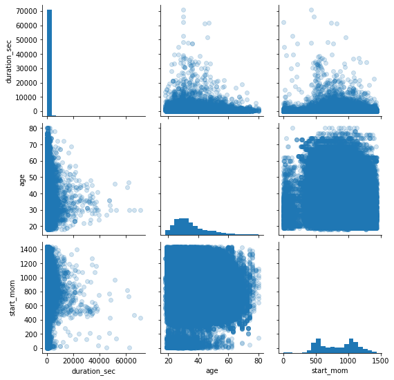

```python
# plot the correlation charts

g = sb.PairGrid(data = bike2, vars = num)
g = g.map_diag(plt.hist, bins = 20);
g.map_offdiag(plt.scatter, alpha=0.2)
```

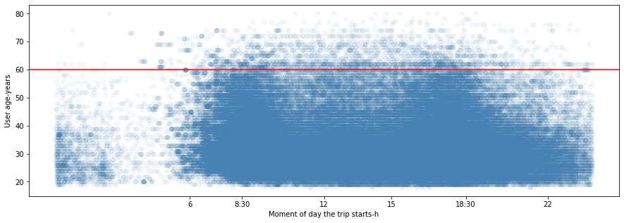

```python
# Plot the enlarged view of start moment vs age
plt.figure(figsize=(15,5))
plt.scatter(data=bike2,y="age",x="start_mom",alpha=0.05,color='steelblue')
plt.ylabel('User age-years');
plt.xlabel('Moment of day the trip starts-h')
plt.xticks([360,500,720,900,1100,1320], ['6','8:30','12', '15','18:30','22'])
plt.axhline(60,color='red')
```

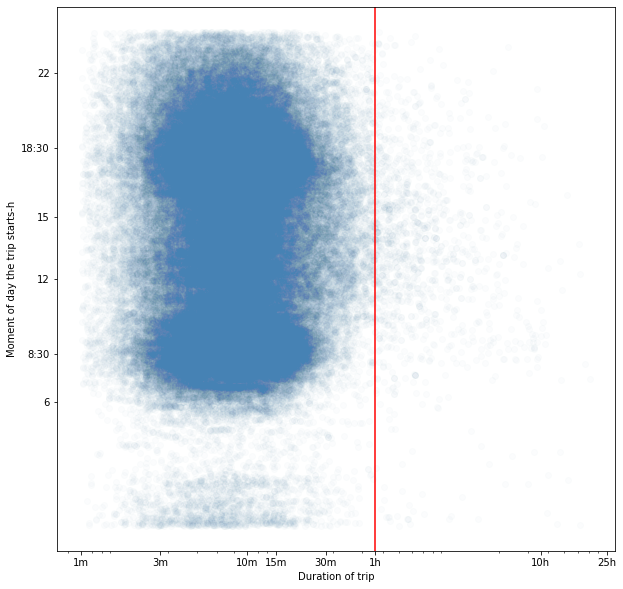

```python
# Plot the enlarged view of start moment vs duration

plt.figure(figsize=(10,10))
plt.scatter(data=bike2,y="start_mom",x="duration_sec",alpha=0.02,color='steelblue')

plt.xscale('log')
plt.xticks([60, 180,600,  900, 1800, 3600, 36000, 90000], ['1m','3m','10m', '15m','30m','1h', '10h', '25h'])
plt.yticks([360,500,720,900,1100,1320], ['6','8:30','12', '15','18:30','22'])
plt.xlabel('Duration of trip');
plt.ylabel('Moment of day the trip starts-h')
plt.axvline(3600,color='red')
```

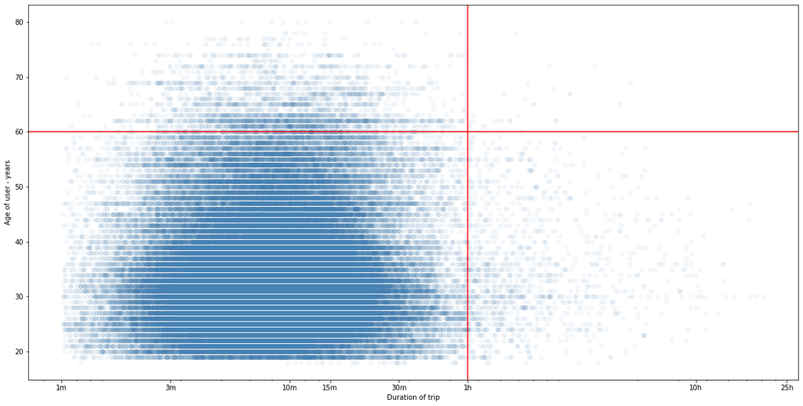

```python
# Plot the enlarged view of duration vs age
plt.figure(figsize=(20,10))
plt.scatter(data=bike2,y="age",x="duration_sec",alpha=0.05,color='steelblue')

plt.xscale('log')
plt.xticks([60, 180,600,  900, 1800, 3600, 36000, 90000], ['1m','3m','10m', '15m','30m','1h', '10h', '25h'])
plt.xlabel('Duration of trip');
plt.ylabel('Age of user - years')

plt.axhline(60,color='red')
plt.axvline(3600,color='red')
```

The linear correlation coefficients are very small so there isn’t any linear correlation. However, looking at the scatter matrix there are some patterns, so I plotted each relationship individually.

Age influence on the start moment of the day: it looks like the people over 60 start they trips in a more uniform pattern (without the 2 peeks in the morning and evening) which is understandable since many are retired and don’t have a schedule to follow.

Link between trip duration and moment of starting it: it seems most of the longer trips are started in the afternoon; this is important since long trips means the bike will be unavailable for the evening peek.

Link between age and trip duration – apparently, people older than 60 take very rarely trips longer than 1h.

Let’s see how the categorical variables come into play.

```python
# compute the logarithm of the duration to make multivariate plotting easier
def log_trans(x, inverse = False):
    """ quick function for computing log and power operations """
    if not inverse:
        return np.log10(x)
    else:
        return np.power(10, x)

bike2['log_duration'] = bike2['duration_sec'].apply(log_trans)
```

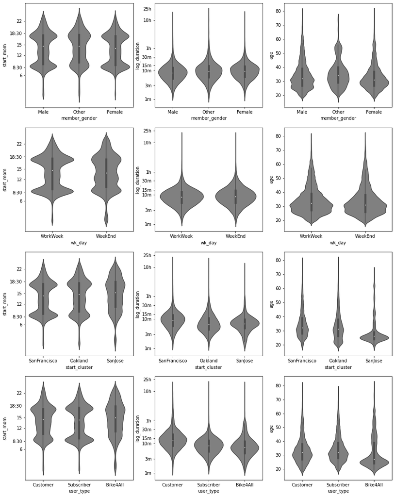

```python
# create violin plots to see the distribution of age, duration and start of the trip,
# differentiated by the categorical variables
fig, ax = plt.subplots(ncols = 3, nrows = 4 , figsize = [15,20])

for i in range(len(categ)):
    var = categ[i]
    sb.violinplot(data = bike2, x = var, y = 'log_duration', ax = ax[i,1],
               color = 'grey')
    ax[i,1].set_yticks(log_trans(np.array([60, 180,600,  900, 1800, 3600, 36000, 90000])))
    ax[i,1].set_yticklabels(['1m','3m','10m', '15m','30m','1h', '10h', '25h'])
    sb.violinplot(data = bike2, x = var, y = 'age', ax = ax[i,2],
               color = 'grey')
    sb.violinplot(data = bike2, x = var, y = 'start_mom', ax = ax[i,0],
               color = 'grey')
    ax[i,0].set_yticks([360,500,720,900,1100,1320])
    ax[i,0].set_yticklabels(['6','8:30','12', '15','18:30','22'])

plt.show()
```

The gender seems to have almost no impact, so I will disregard it.

During the weekend (compared with the workweek) the distribution of the moment of starting a trip has lost almost all its bimodal appearance (the distribution is a lot smoother). The duration and age seem to be mostly not influenced by the day of the week.

The Oakland and San Francisco distributions seem pretty similar, the duration median being a bit lower in Oakland and the age in Oakland having a small peek also in the early 20’s. San Jose shows a very different distribution – the starting moment is not bimodal and is mostly uniform during the day; the age is a lot less varied and mostly concentrated around the mid-20s, as opposed to the other 2 cities where the highest frequency is of early 30’s. Also the duration distribution is a bit narrower in San Jose.

Visually, the user type has a similar influence as the location cluster. The most striking similarity is between the San Jose distributions and the discounted subscriber user type. The main difference between the regular subscribers and the customers is that the customers seem to take longer trips and are not as bound to the bimodal distribution as the subscribers.

Finally, let’s see how the categorical variables interact with each other.

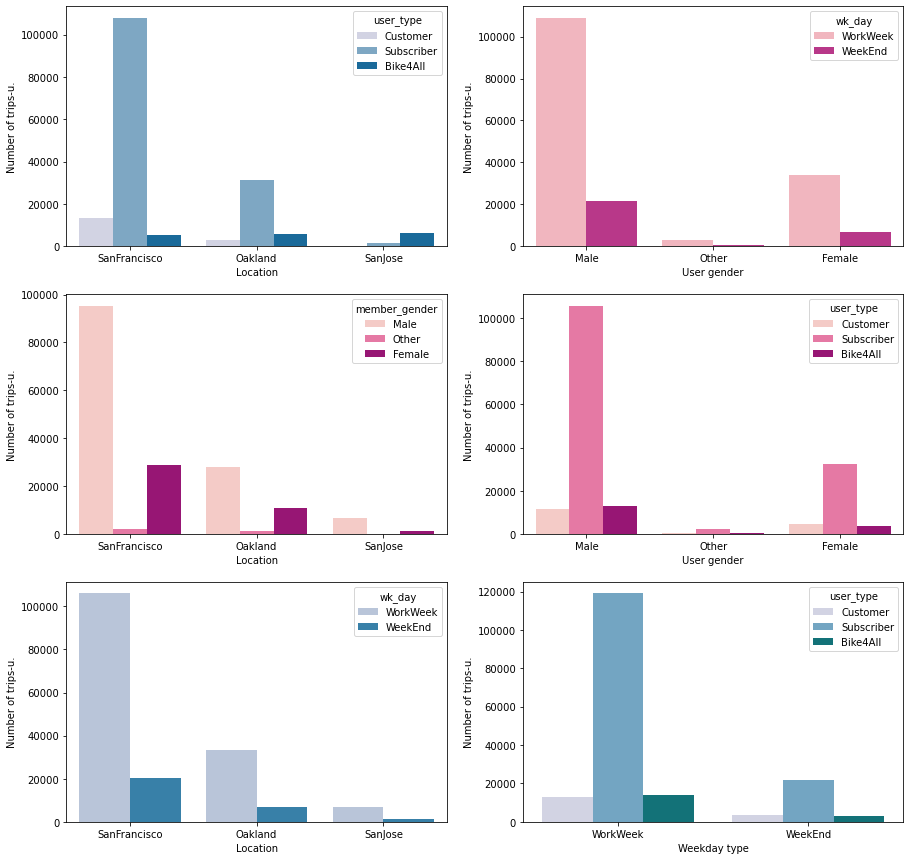

```python
# plot the interaction between categorical var 2 by 2
plt.figure(figsize = [15, 15])

# subplot 1: cluster vs user
ax31=plt.subplot(321)
ax31=sb.countplot(data = bike2, x = 'start_cluster', hue = 'user_type', palette = 'PuBu')
ax31= plt.ylabel('Number of trips-u.')
ax31=plt.xlabel('Location')

# subplot 2: cluster vs wk day
ax32=plt.subplot(325)
ax32=sb.countplot(data = bike2, x = 'start_cluster', hue = 'wk_day', palette = 'PuBu')
ax32= plt.ylabel('Number of trips-u.')
ax32=plt.xlabel('Location')

# subplot 3: cluster vs gender, use different color palette
ax33=plt.subplot(323)
ax33=sb.countplot(data = bike2, x = 'start_cluster', hue = 'member_gender', palette = 'RdPu')
ax33= plt.ylabel('Number of trips-u.')
ax33=plt.xlabel('Location')

# subplot 4: user type vs gender, use different color palette
ax34=plt.subplot(324)
ax34=sb.countplot(data = bike2, x = 'member_gender', hue = 'user_type', palette = 'RdPu')
ax34= plt.ylabel('Number of trips-u.')
ax34=plt.xlabel('User gender')

# subplot 5: gender vs week day, use different color palette
ax35=plt.subplot(322)
ax35=sb.countplot(data = bike2, x = 'member_gender', hue = 'wk_day', palette = 'RdPu')
ax35= plt.ylabel('Number of trips-u.')
ax35=plt.xlabel('User gender')

# subplot 6: week day vs user type
ax36=plt.subplot(326)
ax36=sb.countplot(data = bike2, x = 'wk_day', hue = 'user_type', palette = 'PuBuGn')
ax36= plt.ylabel('Number of trips-u.')
ax36=plt.xlabel('Weekday type')

plt.show()
```

I intentionally colored the plots that have gender as a variable just to double check that indeed the gender is not useful as a differentiator.

The similarity I saw earlier between the influence of San Jose location and discounted type of subscription makes sense now: in SF and Oakland most of the trips are done by regular subscribers and in San Jose most trips are done by users who are subscribes to the discount program. In fact, the number of discount user trips are almost equal between the 2 cities, but the total is a lot different.

The user type and day of week do not seem to influence each other.

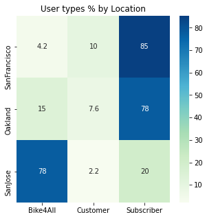

```python
# plot a heatmap of proportion of user types by location

# create a summary table with location on rows and count of users as columns

hm=bike2[['start_cluster','user_type']].copy(deep=True)
subscribers=hm.pivot_table(index='start_cluster', columns='user_type',
                        aggfunc=len, fill_value=0)
subscribers['Bike4All2']=subscribers['Bike4All']*100/(subscribers['Bike4All']+subscribers['Customer']+subscribers['Subscriber'])
subscribers['Customer2']=subscribers['Customer']*100/(subscribers['Bike4All']+subscribers['Customer']+subscribers['Subscriber'])
subscribers['Subscriber2']=subscribers['Subscriber']*100/(subscribers['Bike4All']+subscribers['Customer']+subscribers['Subscriber'])
subscribers.drop(columns=['Bike4All','Customer','Subscriber'],inplace=True)
subscribers.rename(columns={'Bike4All2':'Bike4All','Customer2':'Customer','Subscriber2':'Subscriber'},inplace=True)

# plot the heatmap
fig = plt.figure(figsize=(5,5))
r = sb.heatmap(subscribers, cmap='GnBu', annot = True)
r.set_title("User types % by Location")
plt.xlabel('')
plt.ylabel('') ;
```

### Talk about some of the relationships you observed in this part of the investigation. How did the feature(s) of interest vary with other features in the dataset?

The moment of day a trip starts had no linear correlation with neither age nor trip duration. However, it looks like people older than, let’s say 60, do not comply to the bimodal pattern of trip start and have a more uniform distribution of their trips during the day. Also, it appears the long trips are mostly initiated in the afternoon.

Not surprisingly, during the weekend people tend to need a bike more evenly distributed during the day, as opposed to the weekdays where it’s clear there are the 8:30 and 18:30 peeks. Also the users in San Jose and the ones that subscribed to a discount Share for all program seem to put less pressure during the 8:30/18:30 peeks, and they have a more subtle distribution during the day with a slight increase in the evenings.

### Did you observe any interesting relationships between the other features (not the main feature(s) of interest)?

I noticed that people that are older than 60 rarely take trips longer than 1h. The most striking relationship I found is between the location and user type – apparently San Jose has the majority of trips done by the users with a discount subscription as opposed to SF who’s main riders are regular subscribers. This was shown also when I checked the influence of location and user type on the trip start moment: it seems the location is the cornerstone and each city has a different demographic.

## Multivariate Exploration

The main goal in this section is to put in perspective the relevant interactions I saw before: influence of the city’s demographic on the moment of day a trips starts and its duration.

I will create grid charts to view the interaction between start of trip and duration, by user type and cluster location, first for week days and the for weekends.

Then I will replicate the process for the interaction between start of trip and age – with the same faceting.

```python
# define a function that plots heat maps as a matrix/grid for duration and start of the trip
def hist2dgrid(x, y, **kwargs):
    """ Quick hack for creating heat maps with seaborn's PairGrid. """
    palette = kwargs.pop('color')
    bins_y=np.arange(0,1500,100)
    bins_x=np.arange(np.log10(60),np.log10(3700),(np.log10(1800)-np.log10(900))/3)
    plt.hist2d(x, y, bins=[bins_x,bins_y], cmap = palette, cmin = 0.5)
    plt.xticks([np.log10(60), np.log10(180),np.log10(600),np.log10(900), np.log10(1800), np.log10(3600)], ['1m','3m', '10m','15m','30m','1h'])
    plt.yticks([360,500,720,900,1100,1320], ['6','8:30','12', '15','18:30','22'])
```

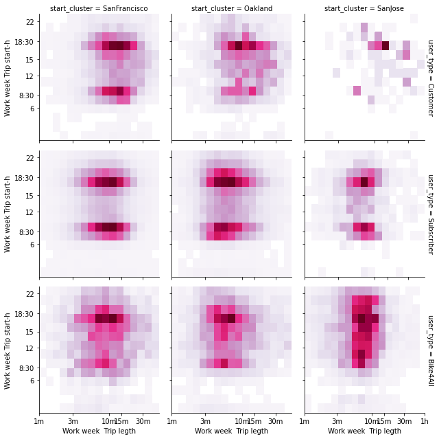

```python
# create faceted heat maps on customer type and location on work days
g = sb.FacetGrid(data = bike2[bike2.wk_day=='WorkWeek'], col = 'start_cluster', row = 'user_type',
                 height= 3, margin_titles=True)
g.map(hist2dgrid,  'log_duration','start_mom', color = 'PuRd')
g.set_ylabels('Work week Trip start-h')
g.set_xlabels('Work week  Trip legth')

plt.show()
```

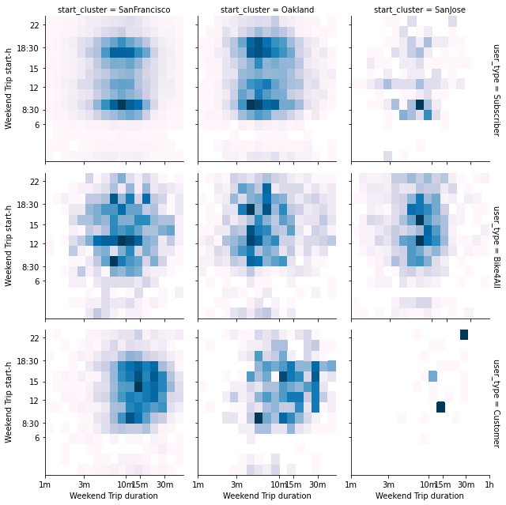

```python
# create faceted heat maps on customer type and location on weekend
g = sb.FacetGrid(data = bike2[bike2.wk_day=='WeekEnd'], col = 'start_cluster', row = 'user_type',
                 height= 3, margin_titles=True)
g.map(hist2dgrid,  'log_duration','start_mom', color = 'PuBu')
g.set_ylabels(' Weekend Trip start-h')
g.set_xlabels('Weekend Trip duration')

plt.show()
```

During the weekend the subscribers have similar behavior as they have during the week for their corresponding cities, in San Jose being a bit less active. The discount subscribers and customers behave similarly during the weekends and they have a demand more evenly distributed during the day.

The duration seems to increase a little bit over the weekends, but it makes sense since probably there are more leisure trips.

```python
# define a function that plots heat maps as a matrix/grid for age and start of the trip

def hist2dgrid2(x, y, **kwargs):
    """ Quick hack for creating heat maps with seaborn's PairGrid. """
    palette = kwargs.pop('color')
    bins_y=np.arange(0,1500,100)
    bins_x=np.arange(20,80,5)
    plt.hist2d(x, y, bins=[bins_x,bins_y], cmap = palette, cmin = 0.5)
    plt.yticks([360,500,720,900,1100,1320], ['6','8:30','12', '15','18:30','22'])
```

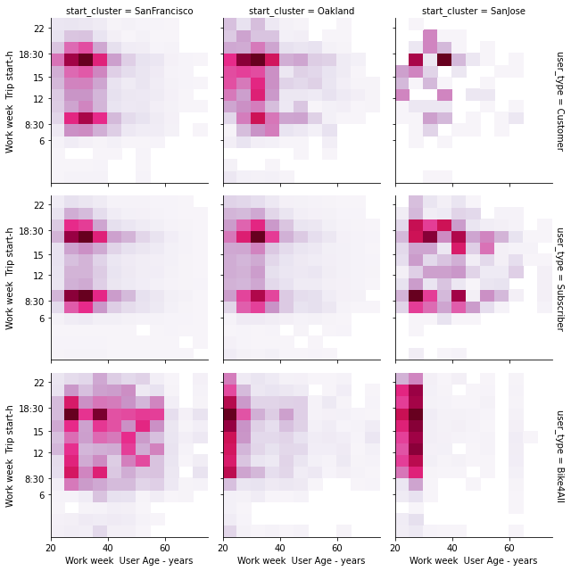

```python
# create faceted heat maps on customer type and age on work days
g = sb.FacetGrid(data = bike2[bike2.wk_day=='WorkWeek'], col = 'start_cluster', row = 'user_type',
                 height= 3, margin_titles=True)
g.map(hist2dgrid2,  'age','start_mom', color = 'PuRd')
g.set_ylabels('Work week  Trip start-h')
g.set_xlabels('Work week  User Age - years')

plt.show()
```

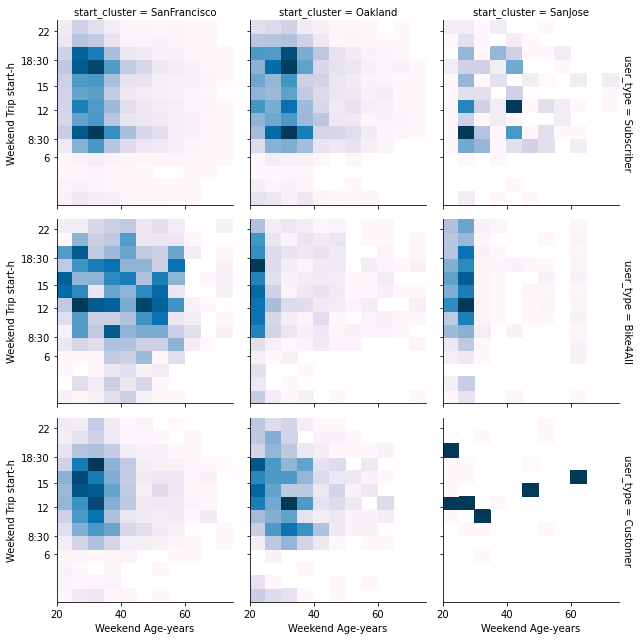

```python
# create faceted heat maps on customer type and age on weekend
g = sb.FacetGrid(data = bike2[bike2.wk_day=='WeekEnd'], col = 'start_cluster', row = 'user_type',
                 height= 3, margin_titles=True)
g.map(hist2dgrid2,  'age','start_mom', color = 'PuBu')
g.set_ylabels('Weekend Trip start-h')
g.set_xlabels('Weekend Age-years')

plt.show()
```

Subscribers and customers seem to be people mostly over 30 that are also the ones demanding the trips during peak times 8:30/18:30 it is mostly visible in SF and Oakland, but San Jose also.

The discounted subscribers are the younger ones – mostly in their 20s – it’s very visible in Oakland and San Jose, but also SF. I expect that Oakland has many students from Berkley so they might be some of the young discount subscribers.

The effect of the weekend is again obvious in terms of leveling the demand across the day. One interesting point is that apparently the activity of the discount subscribers of San Francisco is pretty intense and their age is very diverse.

I will summarize these views in 2 simplified ones : one for weekdays and one for weekends, having the scatterplots by age and start of trip – differentiating the user types by colors.

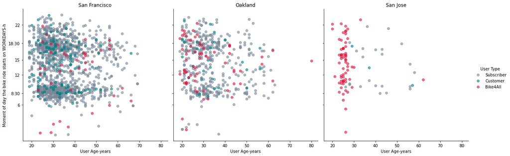

```python
bike_samp = bike2[bike2.wk_day=='WorkWeek'].sample(n=2000, axis=0)
# create faceted heat maps on levels of the cut variable
color_dict = dict({'Subscriber':'lightslategrey',
                  'Bike4All':'crimson',
                  'Customer': 'teal'})
g = sb.FacetGrid(data = bike_samp, col = 'start_cluster', hue='user_type', col_wrap = 3, height= 5.5, palette = color_dict)
g.map(plt.scatter,  'age','start_mom', alpha =0.6)
g.set_ylabels('Moment of day the bike ride starts on WORKDAYS-h')
g.set_xlabels('User Age-years')
g.add_legend(title='User Type')
plt.yticks([360,500,720,900,1100,1320], ['6','8:30','12', '15','18:30','22'])
for ax, title in zip(g.axes.flat, ['San Francisco', 'Oakland', 'San Jose']):
    ax.set_title(title)
plt.show();
```

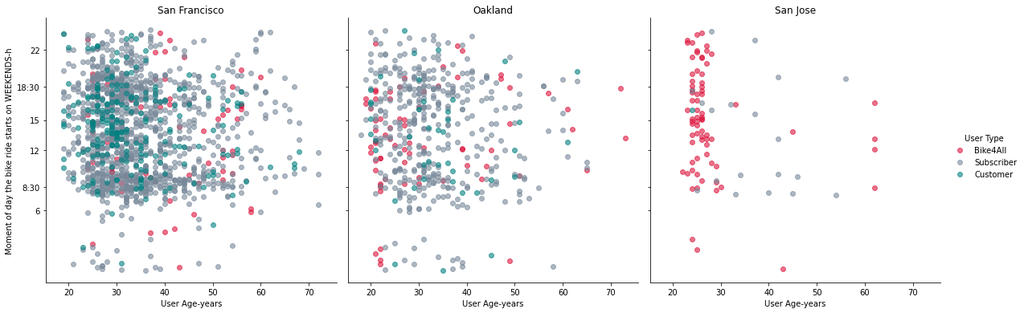

```python
bike_samp = bike2[bike2.wk_day=='WeekEnd'].sample(n=2000, axis=0)
# create faceted heat maps on levels of the cut variable
color_dict = dict({'Subscriber':'lightslategrey',
                  'Bike4All':'crimson',
                  'Customer': 'teal'})
g = sb.FacetGrid(data = bike_samp, col = 'start_cluster', hue='user_type', col_wrap = 3, height= 5.5, palette = color_dict)
g.map(plt.scatter,  'age','start_mom', alpha =0.6)
g.set_ylabels('Moment of day the bike ride starts on WEEKENDS-h')
g.set_xlabels('User Age-years')
g.add_legend(title = 'User Type')
plt.yticks([360,500,720,900,1100,1320], ['6','8:30','12', '15','18:30','22'])

for ax, title in zip(g.axes.flat, ['San Francisco', 'Oakland', 'San Jose']):
    ax.set_title(title)

plt.show();
```

These two views wrap up the most important findings – location is important because the demographics are essentials in each of the 2 cities and it’s the needs of the users that dictate the peaks in demand.

For San Francisco we have mostly Subscribers, with a median age in their early 30s that are driving the peek in demands at 8:30 and 18:30. During the weekend the peaks get smoothed out towards the mid of the day. For San Jose we have mostly discount subscribers that mostly in their late 20’s and they do not drive peaks in demand during the day (whether is work day or weekend).

Oakland is a bit of a mix between the 2: the discounted subscribers are more like the ones in San Jose – in their 20’s (as opposed to San Francisco where they are any age basically) and they have a smooth demand during the day.

Still the majority of users in Oakland are regular subscribers and they too drive the 8:30 and 18:30 peaks during the week – in this respect Oakland is more similar to San Francisco.

There are also customers without subscription – the ones in San Francisco have a behavior and age distribution similar to the regular subscribers; In Oakland they seem more like the discount subscribers. In San Jose they are a very rare.

Now that we saw how important location and demographics are in the demand of bikes at certain moments of time, let’s look also at the hot-spots in each city. The 3 maps below are zoomed views of each city, showing circles where the stations are – the size of the circle indicating the number of trips.

```python
sf_stat=pd.DataFrame(bike2[bike2['start_cluster']=='SanFrancisco']['start_station_name'].value_counts())
sf_stat.reset_index(inplace=True)
sf_stat.rename(columns={'start_station_name':'trips','index':'start_station_name'}, inplace=True)
sf_stat=pd.merge(sf_stat,coord, how='left',on='start_station_name')

o_stat=pd.DataFrame(bike2[bike2['start_cluster']=='Oakland']['start_station_name'].value_counts())
o_stat.reset_index(inplace=True)
o_stat.rename(columns={'start_station_name':'trips','index':'start_station_name'}, inplace=True)
o_stat=pd.merge(o_stat,coord, how='left',on='start_station_name')

sj_stat=pd.DataFrame(bike2[bike2['start_cluster']=='SanJose']['start_station_name'].value_counts())
sj_stat.reset_index(inplace=True)
sj_stat.rename(columns={'start_station_name':'trips','index':'start_station_name'}, inplace=True)
sj_stat=pd.merge(sj_stat,coord, how='left',on='start_station_name')
```

```python
basemap=folium.Map(location=[37.774929,-122.419416], zoom_start=12.7)
plotdata=folium.map.FeatureGroup()

for lat, lon, trips, name in zip(sf_stat['lat'],sf_stat['lon'], sf_stat['trips'],sf_stat['start_station_name']):
    plotdata.add_child(
        folium.CircleMarker(
        [lat,lon],
        radius=0.006*trips,
        popup=name,
        color='red',
        fill=True,
        fill_color='red',
        fill_opacity=0.6))

basemap.add_child(plotdata)
```

Make this Notebook Trusted to load map: File -> Trust Notebook

[interactive chart not shown]

```python
basemap=folium.Map(location=[37.77,-122.25237], zoom_start=12.7)
plotdata=folium.map.FeatureGroup()

for lat, lon, trips, name in zip(sf_stat['lat'],o_stat['lon'], o_stat['trips'],o_stat['start_station_name']):
    plotdata.add_child(
        folium.CircleMarker(
        [lat,lon],
        radius=0.006*trips,
        popup=name,
        color='red',
        fill=True,
        fill_color='red',
        fill_opacity=0.6))

basemap.add_child(plotdata)
```

Make this Notebook Trusted to load map: File -> Trust Notebook

[interactive chart not shown]

```python
basemap=folium.Map(location=[37.33,-121.88], zoom_start=13.5)
plotdata=folium.map.FeatureGroup()

for lat, lon, trips, name in zip(sj_stat['lat'],sj_stat['lon'], sj_stat['trips'],sj_stat['start_station_name']):
    plotdata.add_child(
        folium.CircleMarker(
        [lat,lon],
        radius=0.006*trips,
        popup=name,
        color='red',
        fill=True,
        fill_color='red',
        fill_opacity=0.6))

basemap.add_child(plotdata)
```

Make this Notebook Trusted to load map: File -> Trust Notebook

[interactive chart not shown]

### Talk about some of the relationships you observed in this part of the investigation. Were there features that strengthened each other in terms of looking at your feature(s) of interest?

In this part of the investigation I wanted to put together the hints I got from the previous views – I wanted to see the dynamics of users in each city – what are their ages and what trips do they take and when.

The combined heatmaps revealed how, during workweeks, in San Jose we have trips done mostly by young discount subscribers in their 20’s that are renting bikes all day long but in San Francisco and Oakland we have trips done mostly by subscribers with a higher median age (in their 30’s) that probably use the bike share service to commute towards work and back. The weekend has an effect of leveling the demand during the day in all cities.

### Were there any interesting or surprising interactions between features?

I found it very striking the difference between San Jose customer base and the other 2 cities – especially San Francisco. I imagine the San Francisco has a higher standard of living and the users are mainly professionals as opposed to the other two where there is either a lower standard of living or there are more university student subscribers. I will have to do some research on this topic.